# Homework 8

## Problem 1: The infamous mule kick data 10pts

The file `mule_kicks.csv`, available for download (here)[https://kdlevin-uwstat.github.io/STAT340-Fall2021/hw/03/mule_kicks.csv], contains a simplified version of a very famous data set. The data consists of the number of soldiers killed by being kicked by mules or horses each year in a number of different companies in the Prussian army near the end of the 19th century.

This may seem at first to be a very silly thing to collect data about, but it is a very interesting thing to look at if you are interested in rare events. Deaths by horse kick were rare events that occurred independently of one another, and thus it is precisely the kind of process that we might expect to obey a Poisson distribution.

Download the data and read it into R by running

```r
download.file('https://kdlevin-uwstat.github.io/STAT340-Fall2021/hw/03/mule_kicks.csv', destfile='mule_kicks.csv')
mule_kicks = read.csv('mule_kicks.csv', header=TRUE)

head(mule_kicks)
```

```
##   deaths
## 1      0
## 2      0
## 3      0
## 4      0
## 5      0
## 6      0
```

`mule_kicks` contains a single column, called `deaths`. Each entry is the number of soldiers killed in one corps of the Prussian army in one year. There are 14 corps in the data set, studied over 20 years, for a total of 280 death counts.

### Part a: estimating the Poisson rate 3pts

Assuming that the mule kicks data follows a Poisson distribution, produce a point estimate for the rate parameter $\lambda$. There are no strictly right or wrong answers, here, though there are certainly better or worse ones.

```r
lambda_estimate <- mean(mule_kicks$deaths)
lambda_estimate
```

```
## [1] 0.7
```

### Part b: constructing a CI 4pts

Using everything you know (Monte Carlo, CLT, etc.), construct a confidence interval for the rate parameter $\lambda$. Explain in reasonable detail what you are doing and why you are constructing the confidence interval in this way (a few sentences is fine!).

> To construct a confidence interval for the rate parameter lambda, I am using the Central Limit Theorem (CLT), which suggests that the sampling distribution of the sample mean approximates a normal distribution as the sample size increases, especially for large n. Based on this, I calculate the standard error of lambda as sqrt(var(mule_kicks$deaths)/n), where lambda_estimate is the observed mean rate. I then use a 95% confidence level by applying the critical value of 1.96 from the normal distribution, yielding a confidence interval of lambda_estimate ± (z * SE). This approach provides a reliable estimate for the interval around the rate parameter based on the normal approximation.

```r
# Number of observations
n <- length(mule_kicks$deaths)

# Standard error using lambda estimate
se <- sqrt(var(mule_kicks$deaths)/n)

# Critical value for 95% confidence level
z_value <- qnorm(0.975)  # 1.96 for a 95% CI

# Confidence interval
ci_lower <- lambda_estimate - z_value * se
ci_upper <- lambda_estimate + z_value * se

ci_lower
```

```
## [1] 0.5977054
```

```r
ci_upper
```

```
## [1] 0.8022946
```

> Check with Monte Carlo + graph

```r
total_deaths <- 196
total_period <- 280
lambda_hat <- total_deaths / total_period
M <- 10000

lambda_estimates <- numeric(M)

for (i in 1:M) {
  simulated_data <- rpois(total_period, lambda_hat)
  lambda_estimates[i] <- mean(simulated_data)
}

alpha <- 0.05
lower_bound <- quantile(lambda_estimates, alpha / 2)
upper_bound <- quantile(lambda_estimates, 1 - alpha / 2)

cat("Point estimate for lambda:", lambda_hat, "\n")
```

```
## Point estimate for lambda: 0.7
```

```r
cat("95% Confidence interval for lambda: [", lower_bound, ",", upper_bound, "]\n")
```

```
## 95% Confidence interval for lambda: [ 0.6035714 , 0.8 ]
```

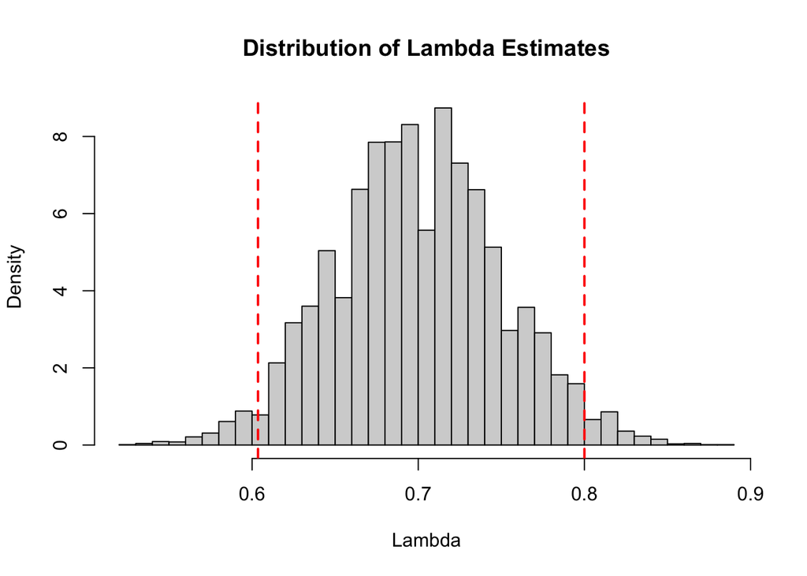

```r
# Plot the distribution of lambda estimates
hist(lambda_estimates, breaks = 30, probability = TRUE, main = "Distribution of Lambda Estimates", xlab = "Lambda")
abline(v = c(lower_bound, upper_bound), col = "red", lwd = 2, lty = 2)
```

### Part c: assessing a model 3pts

Here’s a slightly more open-ended question. We *assumed* that the data followed a Poisson distribution. This may or may not be a reasonable assumption. Use any and all tools that you know to assess (either with code or simply in words) how reasonable or unreasonable this assumption is.

Once again, there are no strictly right or wrong answers here. Explain and defend your decisions and thought processes in a reasonable way and you will receive full credit.

```r
# Calculate mean and variance
sample_mean <- mean(mule_kicks$deaths)
sample_variance <- var(mule_kicks$deaths)

sample_mean
```

```
## [1] 0.7
```

```r
sample_variance
```

```
## [1] 0.762724
```

> A key property of the Poisson distribution is that the mean should equal the variance (lamda). Calculating these values for the deaths column, we find that they are quite similar.

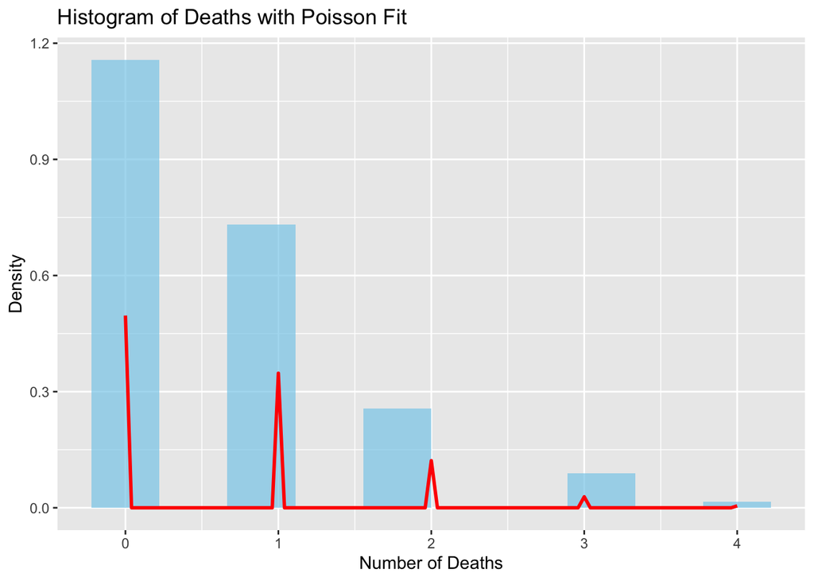

```r
deaths <- mule_kicks$deaths
ggplot(data.frame(deaths), aes(x = deaths)) +
  geom_histogram(aes(y = ..density..), bins = 10, fill = 'skyblue', alpha = 0.7) +
  stat_function(fun = dpois, args = list(lambda = mean(deaths)), color = 'red', size = 1) +
  labs(title = "Histogram of Deaths with Poisson Fit",
       x = "Number of Deaths",
       y = "Density")
```

```r
# Observed counts and expected frequencies
counts <- table(mule_kicks$deaths)
expected_counts <- dpois(as.numeric(names(counts)), lambda = sample_mean) * length(mule_kicks$deaths)

counts
```

```
##
##   0   1   2   3   4
## 144  91  32  11   2
```

```r
expected_counts
```

```
## [1] 139.043885  97.330720  34.065752   7.948675   1.391018
```

```r
# Chi-squared test
chisq_test <- chisq.test(counts, p = expected_counts, rescale.p = TRUE)
chisq_test
```

```
##
##  Chi-squared test for given probabilities
##
## data:  counts
## X-squared = 2.1498, df = 4, p-value = 0.7082
```

> With a Chi-squared statistic of 2.1498 and a p-value of 0.7082, we do not have sufficient evidence to reject the Poisson distribution as a reasonable model for this data.

## Problem 2: A Confidence interval for the median (8 points)

The following numbers were sampled from a population. You can assume they are independent and identically distributed (they are, in fact).

```r
mysteryData <- c(16.91,19.96,16.55,16.77,19.64,16.87,16.50,14.19,16.54,18.64,11.27,17.08)
```

We want to estimate the population median with a 95% confidence interval.

1. First assume that the population is normally distributed. Come up with estimates for the parameters of the normal distribution based on the data.

> In normal distribution the mean equals the median.

```r
mean_estimate <- mean(mysteryData)
sd_estimate <- sd(mysteryData)

mean_estimate
```

```
## [1] 16.74333
```

```r
sd_estimate
```

```
## [1] 2.318065
```

2. Construct a 95% confidence interval assuming the population is a normal distribution. Use the Monte Carlo Approach. Use 1000 Monte Carlo replicates.

```r
set.seed(123)
n_replicates <- 1000
sample_size <- length(mysteryData)

# Monte Carlo simulation
monte_carlo_medians <- replicate(n_replicates, {

  simulated_sample <- rnorm(sample_size, mean = mean_estimate, sd = sd_estimate)

  median(simulated_sample)
})

ci_lower <- quantile(monte_carlo_medians, 0.025)
ci_upper <- quantile(monte_carlo_medians, 0.975)

ci_lower
```

```
##     2.5%
## 15.21944
```

```r
ci_upper
```

```
##    97.5%
## 18.33313
```

3. Now assume that the population is uniformly distributed. Come up with estimates for the min and max of the uniform distribution using the method of moments. This is based on $\bar{X}$, the sample mean and $S$, the sample standard deviation. The point estimates for a and b are given by
   $$\bar{X} \pm \sqrt{3} S$$

```r
a_estimate <- mean_estimate - sqrt(3) * sd_estimate
b_estimate <- mean_estimate + sqrt(3) * sd_estimate

a_estimate
```

```
## [1] 12.72833
```

```r
b_estimate
```

```
## [1] 20.75834
```

4. Construct a 95% confidence interval assuming the population is a uniform distribution. Use 1000 Monte Carlo replicates.

```r
set.seed(123)
n_replicates <- 1000
alpha <- 0.05

# Function to generate a Monte Carlo sample and calculate the sample median
generate_sample_median <- function(a, b, n) {
  sample <- runif(n, min = a, max = b)
  sample_median <- median(sample)
  return(sample_median)
}

# Generate Monte Carlo samples and calculate medians
monte_carlo_medians <- replicate(n_replicates, generate_sample_median(a_estimate, b_estimate, length(mysteryData)))

# Calculate the confidence interval using the quantile function
ci_median_lower <- quantile(monte_carlo_medians, alpha / 2)
ci_median_upper <- quantile(monte_carlo_medians, 1 - alpha / 2)

cat(sprintf("95%% Confidence interval for the population median: [%f, %f]\n", ci_median_lower, ci_median_upper))
```

```
## 95% Confidence interval for the population median: [14.851944, 18.518559]
```

## Problem 3: Closing the loop 6 pts

In our discussion of the Universal Widgets of Madison company from lecture, we said that we were interested in two questions:

1. Estimating the probability $p$ that a widget is functional.
2. How many widgets should be in a batch to ensure that (with high probability) a batch ships with at least $5$ functional widgets in it?

We discussed question (1) at length in lecture. What about question (2)? Our client wants to know how many widgets should ship in each batch so as to ensure that the probability there are at least $5$ functional widgets in a batch is at least $0.99$.

Now, suppose that we have observed data and estimated $p$ to be $0.82$.

Use everything you know so far in this course to give a recommendation to the client. Be sure to explain clearly what you are doing and why. If there are any steps, assumptions, etc., that you are not 100% pleased with, feel free to point them out.

**Note:** there are at least two “obvious” ways to solve this problem. One is based on using Monte Carlo (i.e., assume $p=0.82$ is the truth, and try generating batches of different sizes, etc.). The other uses direct computation of probabilities, using basic facts about Binomial RVs. Neither of these is necessarily better than the other, and you do not need to use both approaches to receive full credit. Indeed, you are free to try doing something else entirely, if you wish. Just explain clearly what you are doing and why!

> Approach with Monte Carlo:

```r
set.seed(123)

p <- 0.82

# Function to simulate a batch of widgets and check if at least 5 are functional
simulate_batch <- function(batch_size) {
  # Generate a batch of widgets, 1 represents functional, 0 non-functional
  batch <- rbinom(batch_size, 1, p)
  # Check if at least 5 widgets are functional (i.e., sum of 1's in the batch)
  return(sum(batch) >= 5)
}

# Function to estimate the minimum batch size for 99% probability
find_batch_size <- function(target_prob, max_size = 200) {
  for (batch_size in 5:max_size) {
    # Simulate 10000 batches and check the proportion with at least 5 functional widgets
    results <- replicate(10000, simulate_batch(batch_size))

    # Calculate probability of having at least 5 functional widgets in a batch
    prob_at_least_5 <- mean(results)

    cat("Batch size:", batch_size, "Probability of at least 5 functional widgets:", prob_at_least_5, "\n")

    if (prob_at_least_5 >= target_prob) {
      return(batch_size)
    }
  }
  return(NA) # if no size meets the probability
}

# Find the minimum batch size that ensures at least 5 functional widgets with 99% probability
min_batch_size_mc <- find_batch_size(0.99)
```

```
## Batch size: 5 Probability of at least 5 functional widgets: 0.3736
## Batch size: 6 Probability of at least 5 functional widgets: 0.7023
## Batch size: 7 Probability of at least 5 functional widgets: 0.8843
## Batch size: 8 Probability of at least 5 functional widgets: 0.9569
## Batch size: 9 Probability of at least 5 functional widgets: 0.9878
## Batch size: 10 Probability of at least 5 functional widgets: 0.9962
```

```r
cat("Monte Carlo Approach - Minimum batch size:", min_batch_size_mc, "\n")
```

```
## Monte Carlo Approach - Minimum batch size: 10
```

> For the Monte Carlo method, I simulated batches of varying sizes and calculated the probability of having at least 5 functional widgets in each batch, iterating until I found the smallest batch size that met the required probability of 0.99.

> Approach with Binomial Distribution:

```r
p <- 0.82
required_prob <- 0.99

# Function to calculate the minimum batch size
min_batch_size <- function(p, required_prob) {
  for (n in 1:1000) {
    prob <- 1 - pbinom(4, n, p)  # Probability of having at least 5 functional widgets
    if (prob >= required_prob) {
      return(n)
    }
  }
  return(NULL)
}

# Calculate the minimum batch size
batch_size <- min_batch_size(p, required_prob)

cat("The minimum batch size to ensure at least 5 functional widgets with a probability of at least", required_prob, "is", batch_size, ".\n")
```

```
## The minimum batch size to ensure at least 5 functional widgets with a probability of at least 0.99 is 10 .
```

> For the binomial distribution method, I used the cumulative distribution function (CDF) of the binomial distribution to directly calculate the probability of having at least 5 functional widgets in a batch, and identified the minimum batch size that satisfies the 0.99 probability requirement.

> Based on both the Monte Carlo and Binomial Distribution methods, the minimum batch size required to ensure that there are at least 5 functional widgets with a probability of at least 0.99 is 10.

## Problem 4: Estimating Coverage Rate (6 points)

Suppose we want to estimate the $p$ parameter from a Geometric distribution. By doing some research you would find that an unbiased estimator for $p$ is given as:

$$\hat{p} =
\frac{1}{1+\frac{n}{n-1}\bar{X}}$$

1. Create a plot that shows the coverage rate of a 95% confidence interval for samples of size 12 for values of p: .10, .20, …, .80, .90.
- To estimate the coverage rate, use 500 Monte Carlo replicates
- To construct each MC interval you should use 500 MC replicates

If this is taking too long to run, lower both of these to 200 replicates.

> p = 1/(1+x_hat)

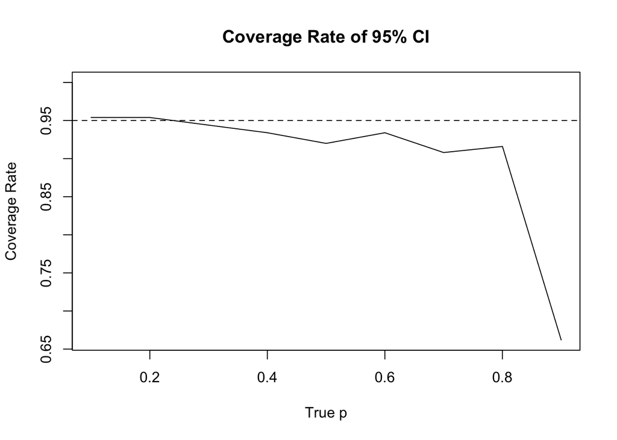

```r
set.seed(1)
p_values <- seq(0.1, 0.9, 0.1)
coverage <- rep(0, length(p_values))
results <- data.frame(p = p_values, coverage = coverage)
NMC1 <- 500
NMC2 <- 500
n <- 12

for (j in 1:nrow(results)) {
  p <- results$p[j]
  contains <- rep(FALSE, NMC1)

  for (i in 1:NMC1) {
    # Generate data from the geometric distribution
    data <- rgeom(n, p)
    x_bar <- mean(data)

    # Calculate the unbiased estimate of p
    p_hat <- 1 / (1 + (n / (n - 1)) * x_bar)

    # Generate NMC2 sets of data using p_hat
    p_hat_samples <- replicate(NMC2, {
      sample_data <- rgeom(n, p_hat)
      sample_x_bar <- mean(sample_data)
      1 / (1 + (n / (n - 1)) * sample_x_bar)
    })

    # Calculate the 95% confidence interval
    ci_lower <- quantile(p_hat_samples, 0.025)
    ci_upper <- quantile(p_hat_samples, 0.975)

    # Check if the true p is within the confidence interval
    contains[i] <- (p >= ci_lower) & (p <= ci_upper)
  }

  # Calculate the coverage rate
  results[j, "coverage"] <- mean(contains)
}

plot(x = results$p, y = results$coverage, ylim = c(min(results$coverage), 1), type = "l",
     xlab = "True p", ylab = "Coverage Rate", main = "Coverage Rate of 95% CI")
abline(h = 0.95, lty = 2)
```

2. What do you observe? Does the coverage of MC intervals tend to be affected by the value of $p$? In what way?
> 1. Small ( p ) Values: For small values of ( p ) (up to around 0.3), the estimator p hat tends to perform well, and the coverage rate is close to the nominal 95%. This is because the variance of the estimator is relatively low, and the distribution of the estimator is more symmetric.
> 2. Moderate ( p ) Values: As ( p ) increases towards 0.5, the variance of the estimator increases, and the distribution becomes more skewed. This can lead to wider confidence intervals that may not capture the true ( p ) as effectively, resulting in a drop in the coverage rate.
> 3. Extreme ( p ) Values: For very high values of ( p ) (close to 0.9), the estimator p hat becomes highly variable and biased. The confidence intervals become less reliable, and the coverage rate drops sharply.